# Intervalos de confianza

# Comparando los dos métodos

Sobre la amplitud del intervalo ya hemos visto que influyen el nivel de confianza y el error estándar. Este último expresa la incertidumbre que tenemos al trabajar con muestras. Su valor está determinado por la variabilidad de los valores, pero también por el tamaño de la muestra.  
Vamos a estudiar el comportamiento del intervalo de confianza, usando el método de bootstrapping, cuando tenemos diferentes valores del tamaño de la muestra. En este caso, haremos el estudio de muestras con tamaños de 5, 8, 11, … hasta 30 individuos.

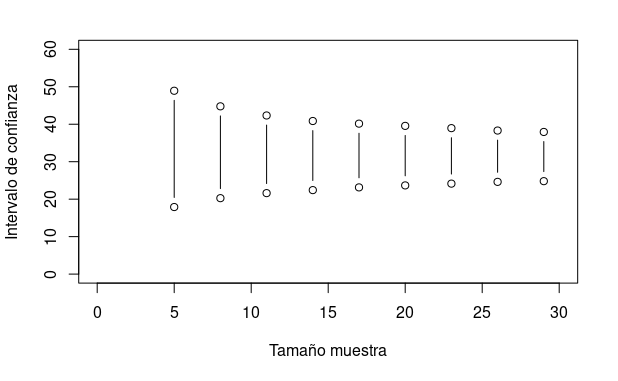

```r
plot(c(0,30),c(0,60),type="n",xlab = "Tamaño muestra", ylab = "Intervalo de confianza") # Gráfica de los intervalos
for(k in seq(5,30,3)) {
  a <- numeric(10000) #Variable para anotar medias muestrales
  for(i in 1:10000){  #Bucle para repetir 10000 veces el muestreo
    a[i] <- mean(sample(values,k,replace = T)) #Obtiene una muestra n=10 y calcula la media
  }
  points(c(k,k), quantile(a,c(0.025,0.975)),type="b") #Representación de cada intervalo
}
```

A continuación, veamos cómo se modifican los intervalos de confianza calculados con los valores de la distribución *t de Student*.

```r
plot(c(0,30),c(0,60),type="n",xlab = "Tamaño muestra", ylab = "Intervalo de confianza") # Gráfica de los intervalos
for(k in seq(5,30,3)) {
  a <- numeric(10000) #Variable para anotar medias muestrales
  for(i in 1:10000){  #Bucle para repetir 10000 veces el muestreo
    a[i] <- mean(sample(values,k,replace = T)) #Obtiene una muestra n=10 y calcula la media
  }
  points(c(k,k), quantile(a,c(0.025,0.975)),type="b") #Representación de cada intervalo
}
```

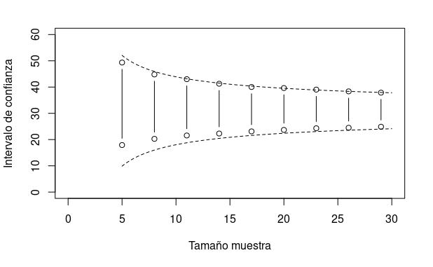

```r
xv <- seq(5,30,0.1)
yv <- mean(values)-qt(0.975,xv)*sqrt(var(values)/xv)
lines(xv,yv,lty=2)
yv <- mean(values)+qt(0.975,xv)*sqrt(var(values)/xv)
lines(xv,yv,lty=2)
```